# ggplot2 Exercises Solution

## 2.3.1 Exercises

1. Relationship between cty and hwy.

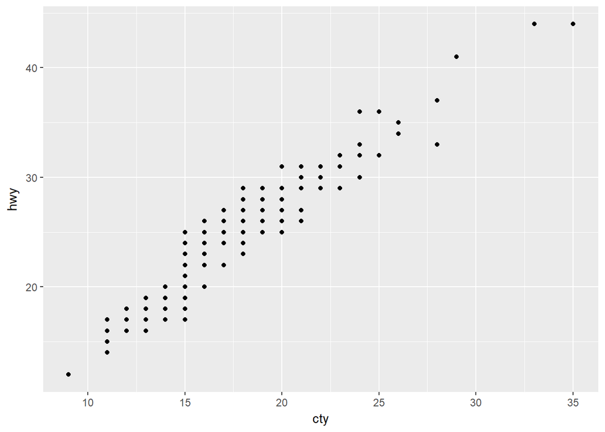

```r
mpg %>% ggplot(aes(cty, hwy)) +
  geom_point()
```

- Relationship is linear, positive, and strong without any glaring outliers. The only concern I have about the plot is that *it is almost too perfect*. Perhaps multicollinearity?

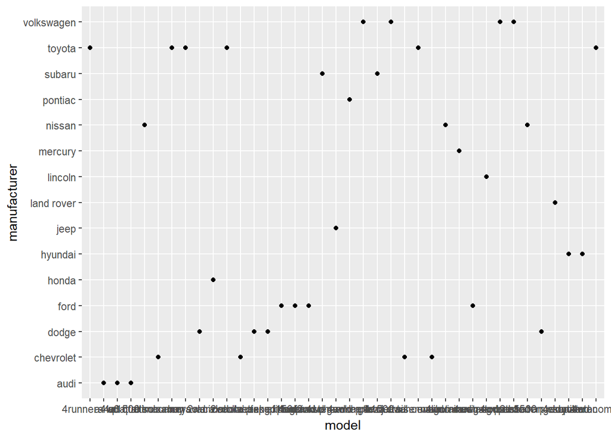

- The problem is there are too many x-axis labels, so its impossible to read the values. One fix would be to shorten the model names: get rid of drv values ,manufacturers, and spaces. If this does not suffice, rotate the x-axis values 90 degrees.
3. The first two graphs will be scatterplots. #1 graph will have a high correlation and be linear, as we saw above. #2 graph should show a positive relationship (common sense?). #3 graph will be a line graph that changes with time (x-axis). #4 graph will be a histogram with counts of cty on the y-axis.

## 2.4.1 Exercises

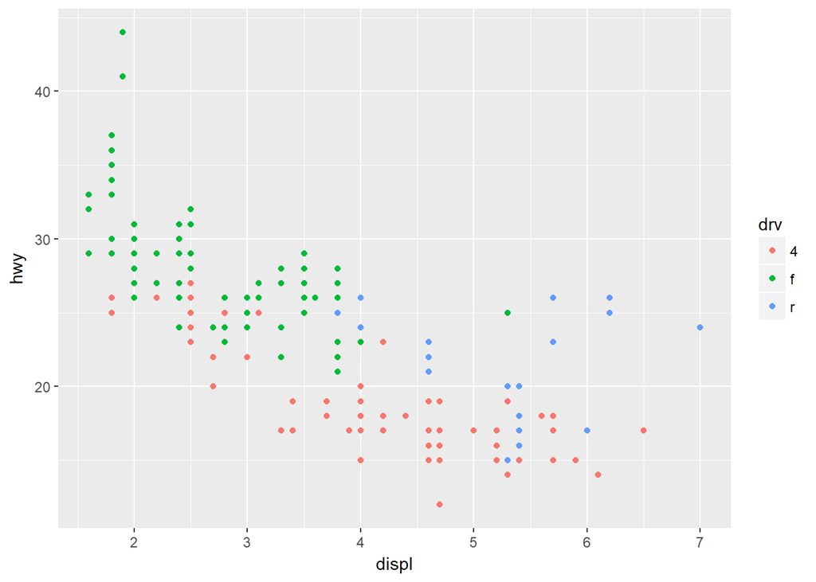

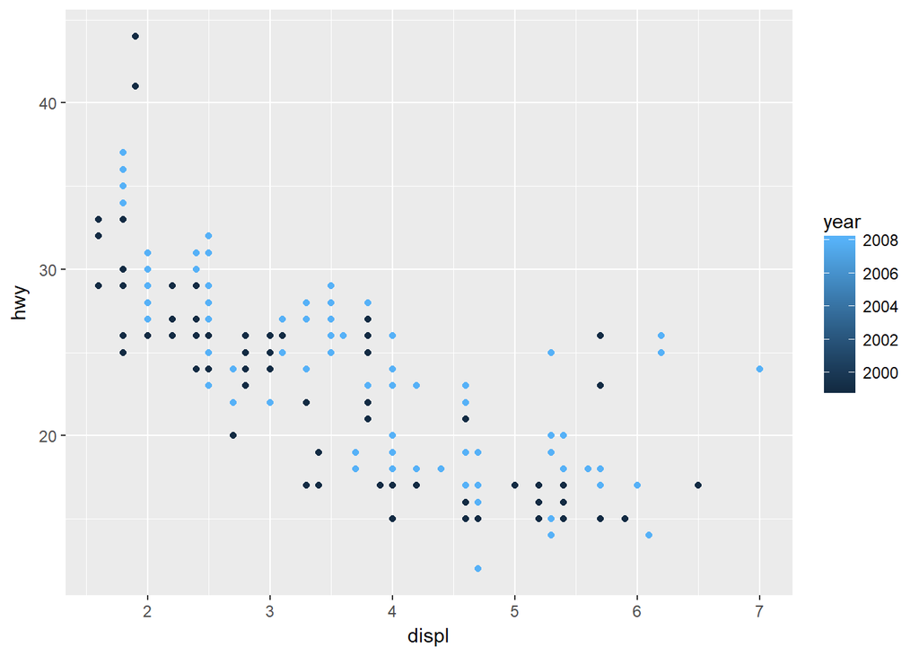

- Based upon these graphs, mapping color to categorical variable is informative while mapping it to continiuous variable is not.

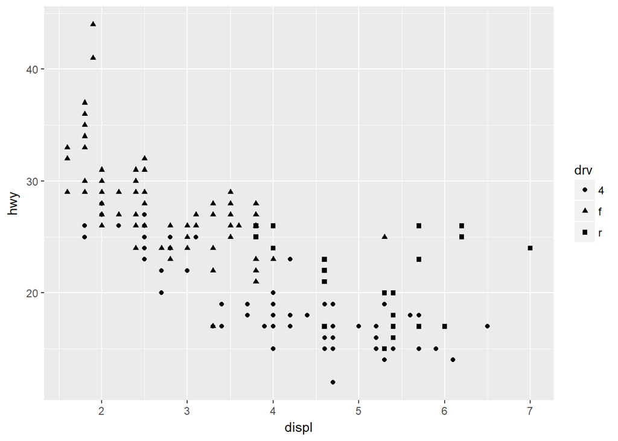

```
Error: A continuous variable can not be mapped to shape
```

Mapping categorical variable to shape works (produces a graph), but readability is very poor. Mapping to continuous variable throws an error

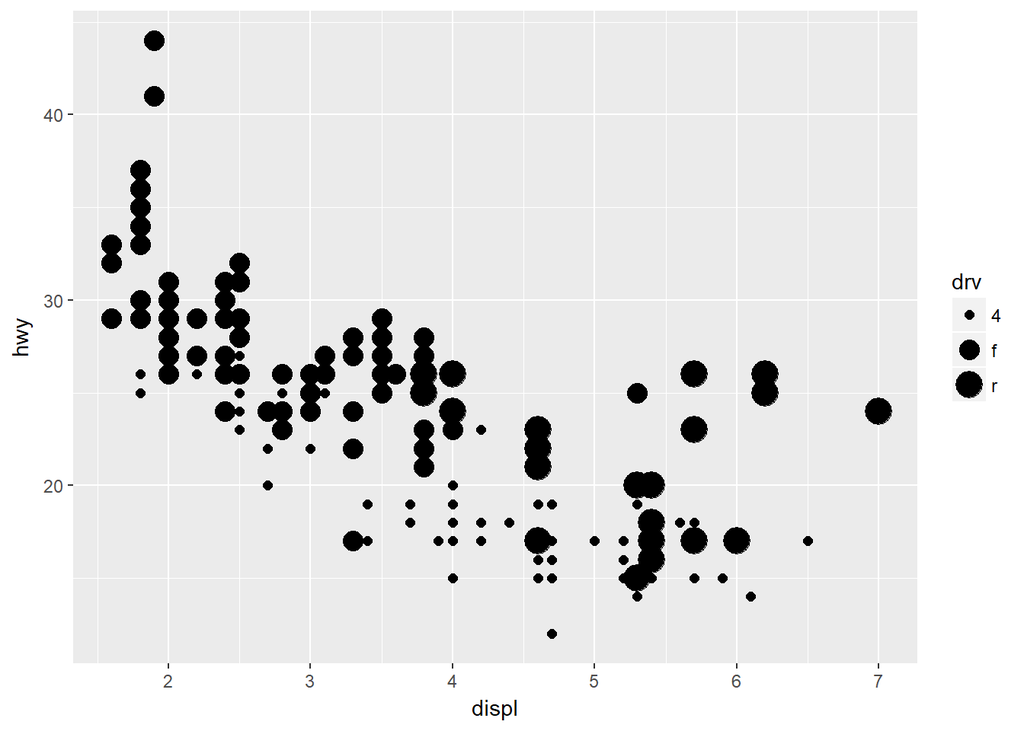

```r
# Mapping to categoorical variable
ggplot(mpg, aes(displ, hwy)) +
  geom_point(aes(size = drv))
```

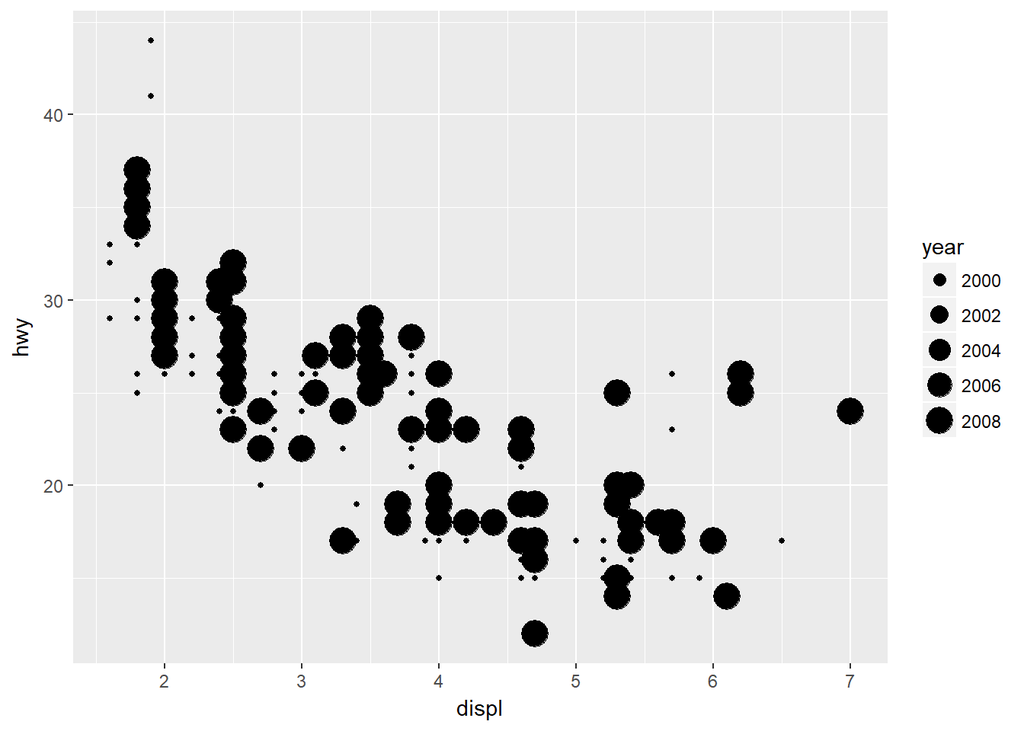

```r
# Mapping to continuous variable
ggplot(mpg, aes(displ, hwy)) +
  geom_point(aes(size = year))
```

* Mapping categorical/continuous variable to size works, but readbility is very poor.

- Using 2 aesthetics in a plot

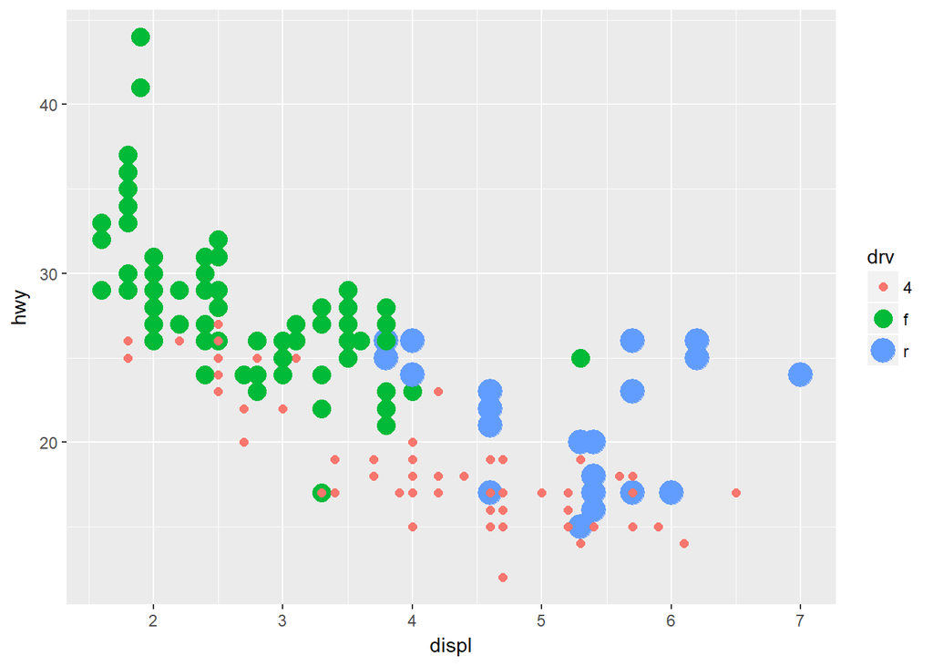

* Ah, readability is much better.

2. When you map a continuous variable to shape, you get an error. Why:The shape palette can deal with a maximum of 6 discrete values because more than 6 becomes difficult to discriminate (ggplot2 documentation).

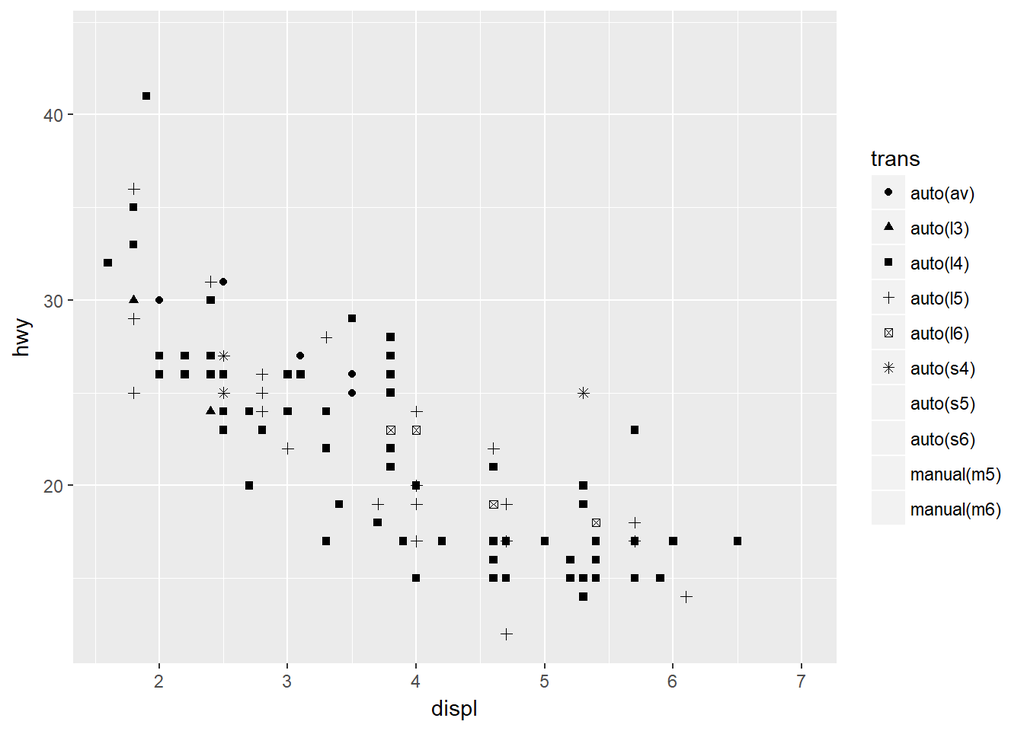

* ggplot2 only takes 6 discrete values! If we want more shapes, we have to manually designate them.

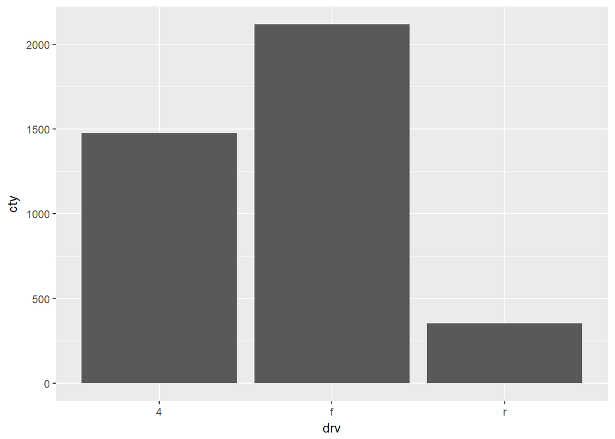

- Looks like “f” has the most fuel economy, followed by “4” and “r”

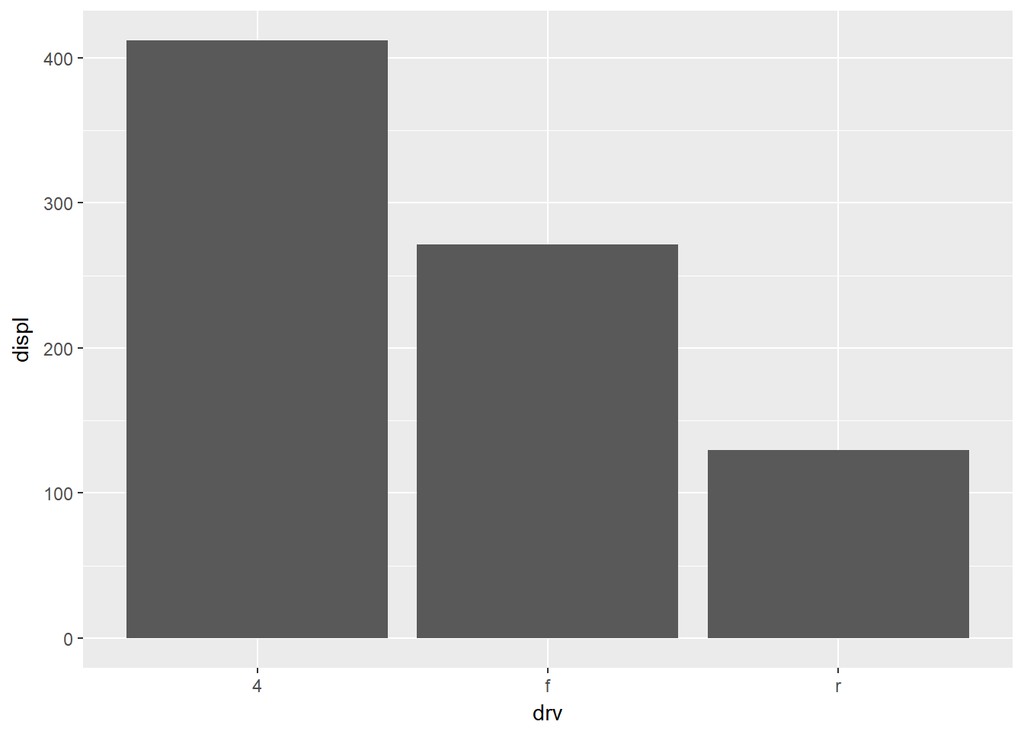

```r
ggplot(mpg, aes(drv, displ)) +
  geom_bar(stat = "identity")
```

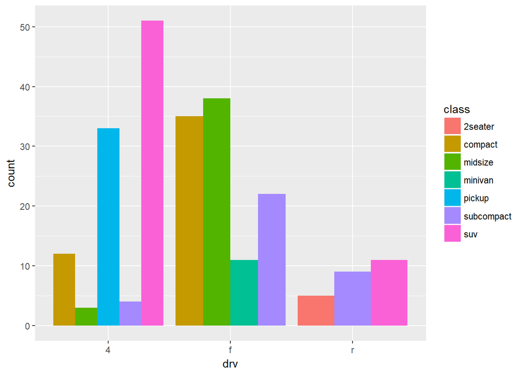

```r
ggplot(mpg, aes(drv, ..count..)) +
  geom_bar(aes(fill = class), position = "dodge")
```

## 2.5.1 Exercises

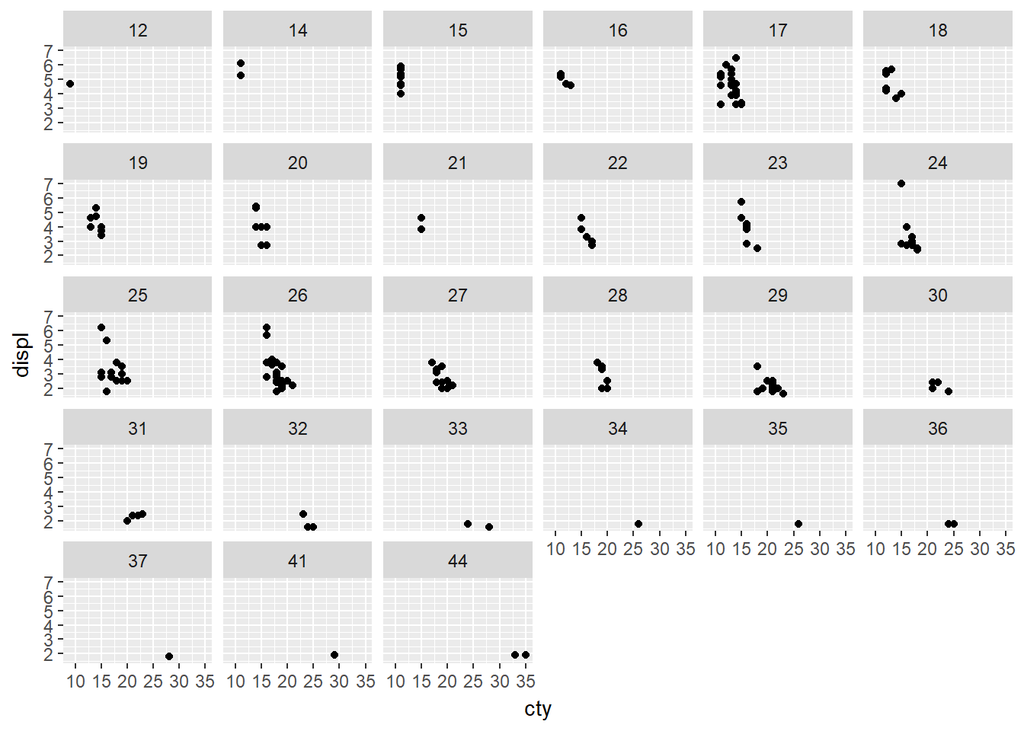

```r
# library(tidyverse)
ggplot(mpg, aes(cty, displ)) +
  geom_point() +
  facet_wrap(~hwy)
```

* When faceting by a continuous variable hwy, I get alot of graphs here with little information in each graph. I don’t imagine these graphs to be useful.

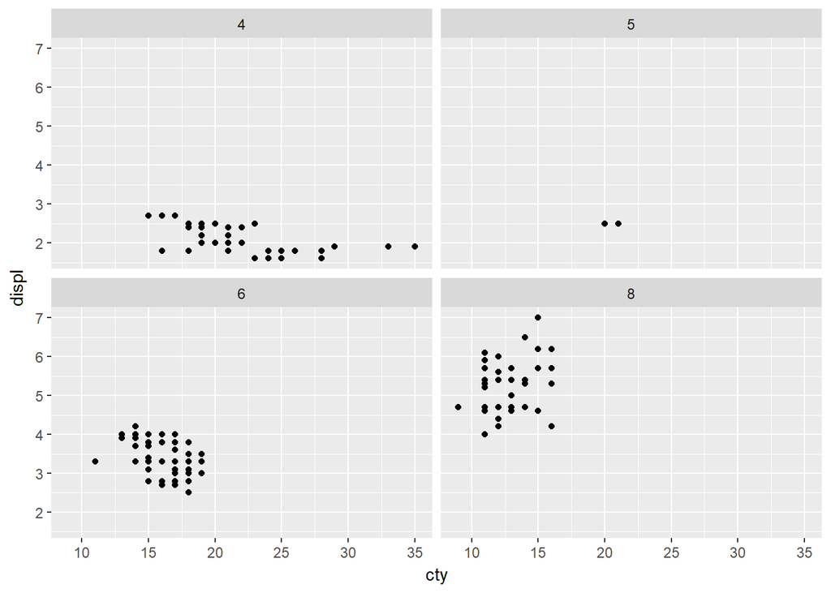

```r
ggplot(mpg, aes(cty, displ)) +
  geom_point() +
  facet_wrap(~cyl)
```

* You see some information for all the cylinders except 5 cylinder graph.

- I think the key difference is that a continous variable has so many values that its impossible to get alot of information for each faceted graph. It has minimal information. On the other hand, for categorical variables, there are not many facetted graphs, so you get a reasonable amount of information from each graph.

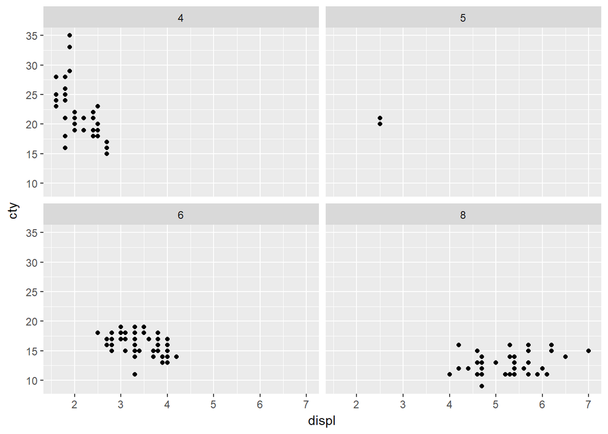

```r
ggplot(mpg, aes(displ, cty)) +
  geom_point() +
  facet_wrap(~cyl)
```

* First, you can’t really say much about 5 cylinder cars since there are only two data points for them. for 4 cylinder cars, most cars have small engine displacement and high fuel economy (compared to 6 and 8 cylinder cars). For 6 cylinder cars, the engine displacement ranges from 3 to 4 liters, but has low fuel economy. Last, for 8 cylinder cars, it is on the high range of engine displacement, but has low fuel economy.

```r
?facet_wrap
```

```
starting httpd help server ... done
```

- You can adjust nrow, ncol arguments to control how many rows / columns in the output.
4. The documentation says, “should Scales be fixed (”fixed“, the default), free (”free“), or free in one dimension (”free_x“,”free_y“).”

## 2.6.6 Exercises

1. x values and y values are closely related (multicollinearity?)

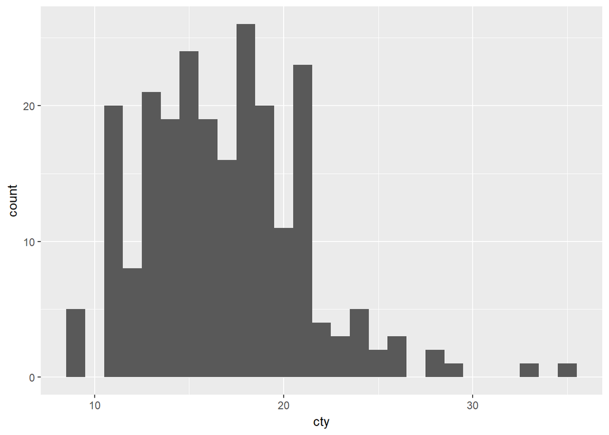

```r
# To remedy the problem, graph two separate histograms
ggplot(mpg, aes(cty)) +
  geom_histogram(binwidth = 1)
```

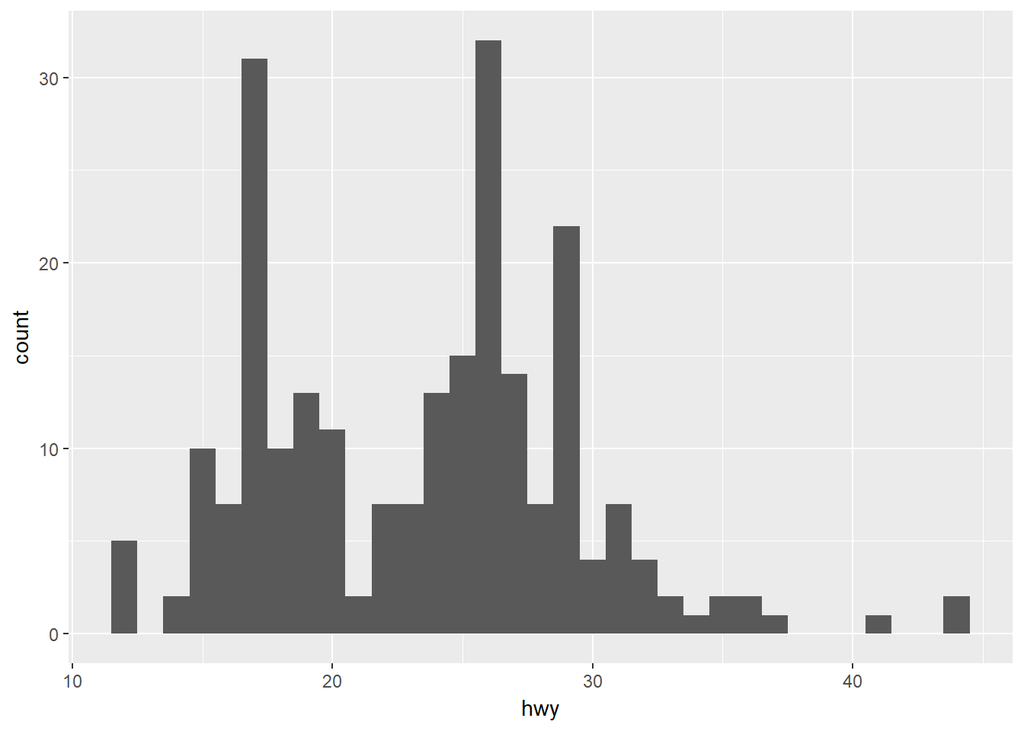

```r
ggplot(mpg, aes(hwy)) +
  geom_histogram(binwidth = 1)
```

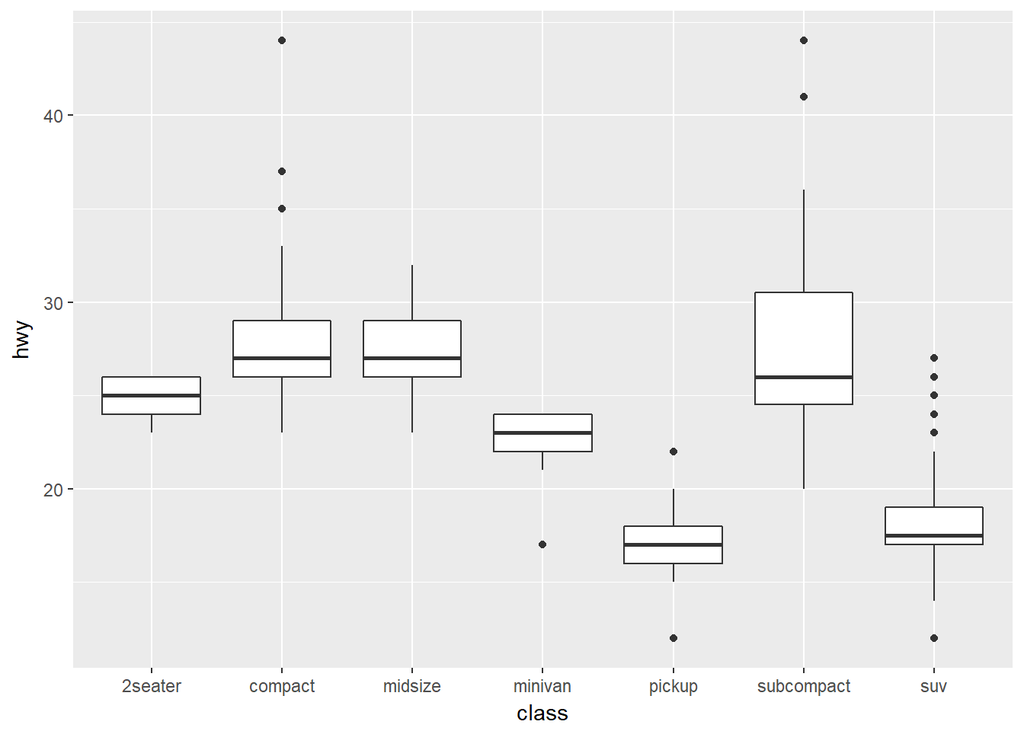

```r
ggplot(mpg, aes(class,hwy)) +
  geom_boxplot()
```

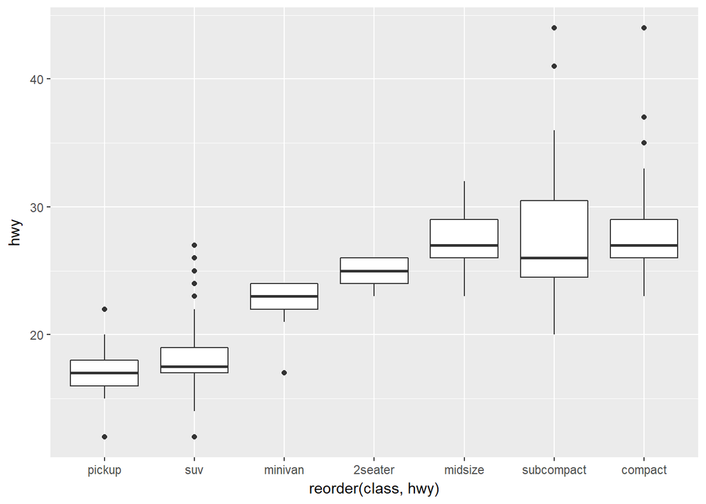

```r
ggplot(mpg, aes(reorder(class,hwy), hwy)) +
  geom_boxplot()
```

- reorder(class, hwy) reorders class levels based on values of hwy.

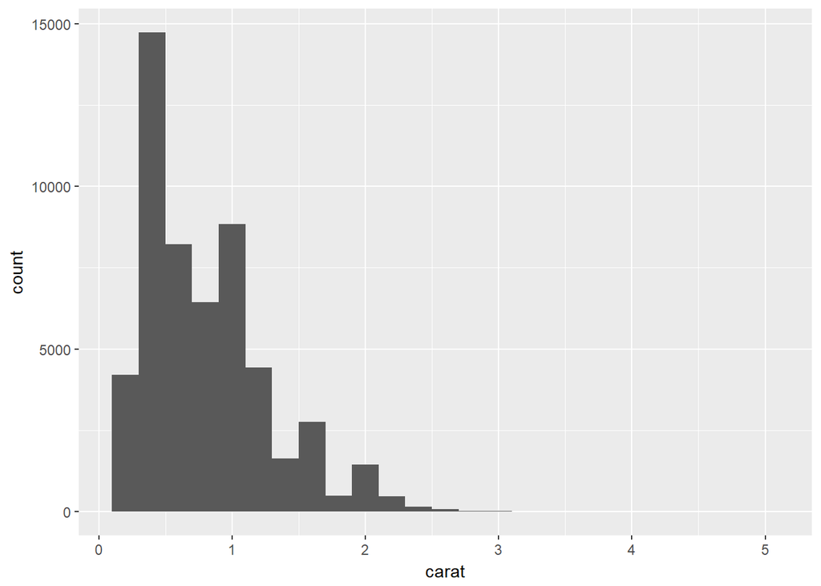

```r
ggplot(diamonds, aes(carat)) +
  geom_histogram(binwidth = 0.2)
```

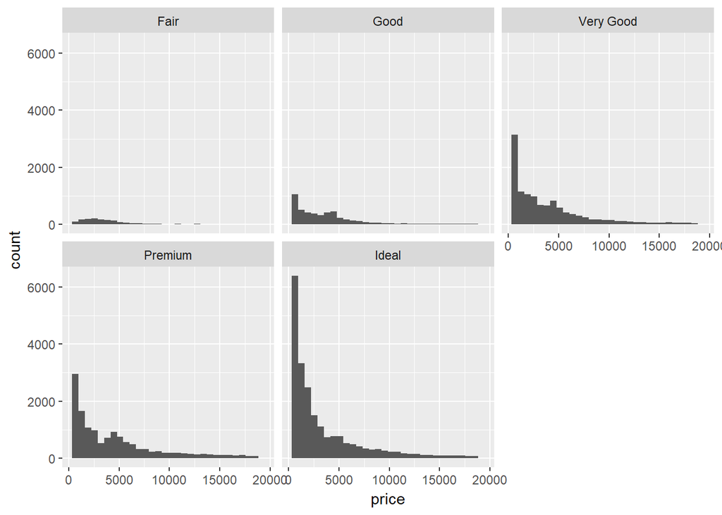

```r
ggplot(diamonds, aes(price)) +
  geom_histogram() +
  facet_wrap(~cut)
```

5. Violin plots give richest display, but rely on distribution of a density estimate, which can be hard to interpret.

*Help with geom_freqpoly with colors and geom_histogram with faceting*

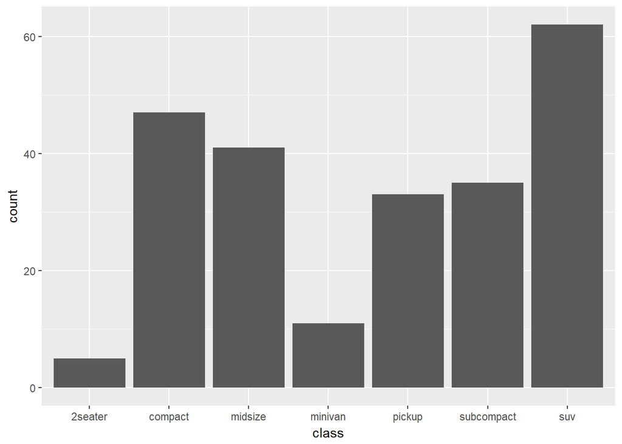

```r
?geom_bar()
g <- ggplot(mpg, aes(class))
# Number of cars in each class:
g + geom_bar()
```

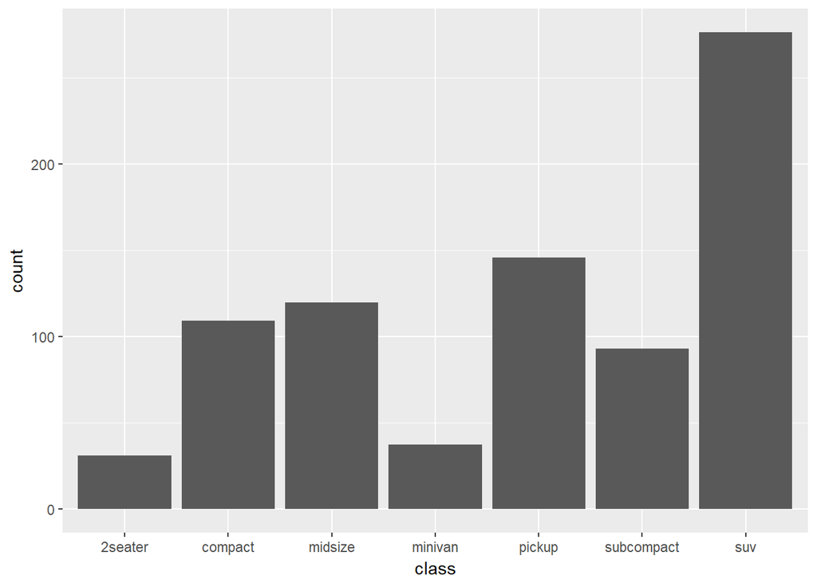

```r
# Total engine displacement of each class
g + geom_bar(aes(weight = displ))
```

- weight aesthetic in the above code “weights” the number of cars in each class according to engine displacement.
7. [Amanda’s solutions](https://github.com/AmandaRP/ggplot2-exercises/blob/master/Chapter2.Rmd)

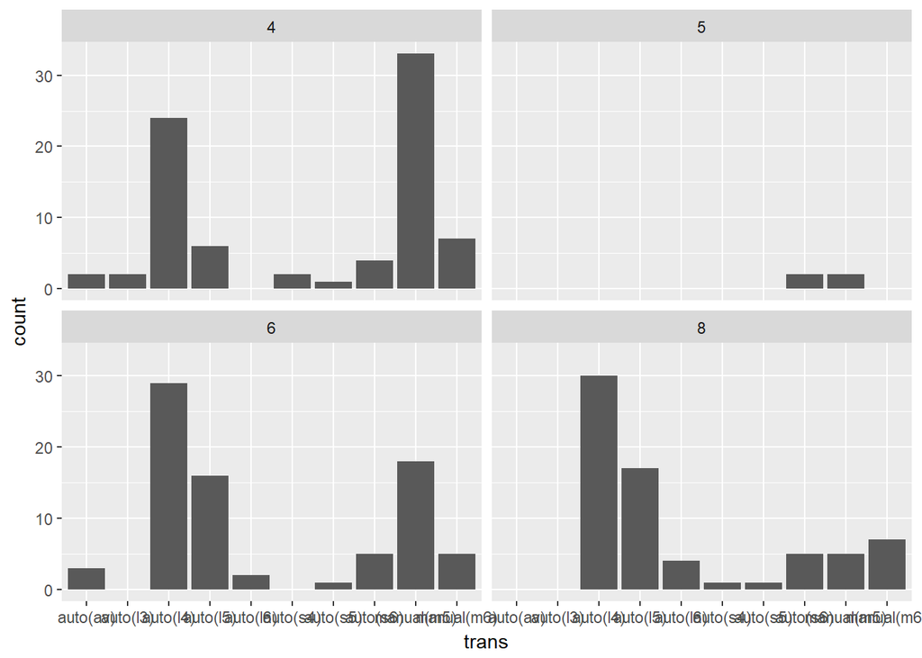

```r
# The following is a bar chart of trans with faceting on cyl.
ggplot(mpg,aes(trans)) + geom_bar() + facet_wrap(~cyl)
```

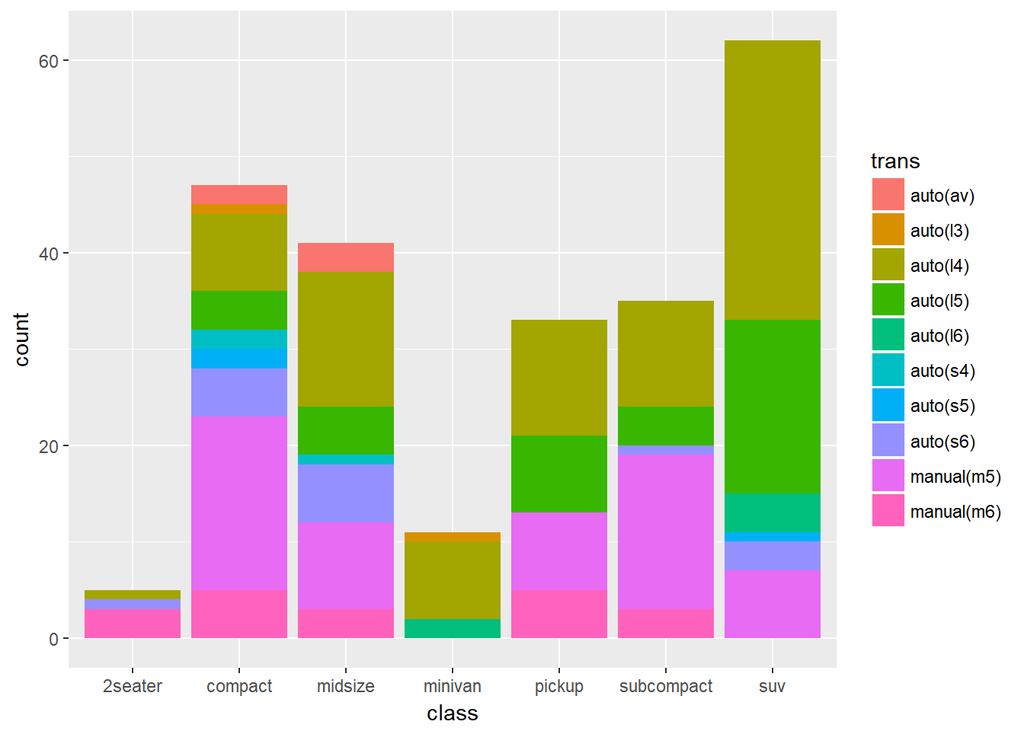

```r
# We can also use a bar chart with stacking:
ggplot(mpg,aes(class)) + geom_bar(aes(fill=trans))
```

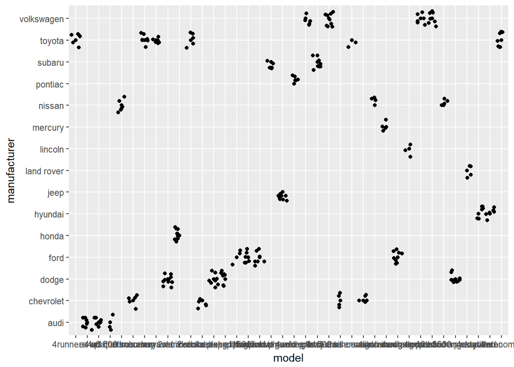

```r
# it shows model by manufacturer with jitter turned on.
ggplot(mpg,aes(model,manufacturer)) + geom_point() + geom_jitter()
```

## 3.2.1 Exercises

- Scatterplot: geom_point()
- Line Chart: geom_line()
- Histogram: geom_histogram()
- Bar chart: geom_bar()
- Pie chart: According to http://ggplot2.tidyverse.org/reference/coord_polar.html , the polar coordinate system is most commonly used for pie charts, which are a stacked bar chart in polar coordinates. A pie chart = stacked bar chart + polar coordinates (geom_bar() + coord_polar())
2. Polygons are very similar to paths (as drawn by geom_path) except that the start and end points are connected and the inside is coloured by fill. The group aesthetic determines which cases are connected together into a polygon. geom_path() connects the observations in the order in which they appear in the data. geom_line() connects them in order of the variable on the x axis.
3. *Not sure what Hadley means by low-level geoms* Here is some information on parameters used in geom_smooth(). http://ggplot2.tidyverse.org/reference/geom_smooth.html geom_boxplot(): http://ggplot2.tidyverse.org/reference/geom_boxplot.html geom_violin(): http://ggplot2.tidyverse.org/reference/geom_violin.html

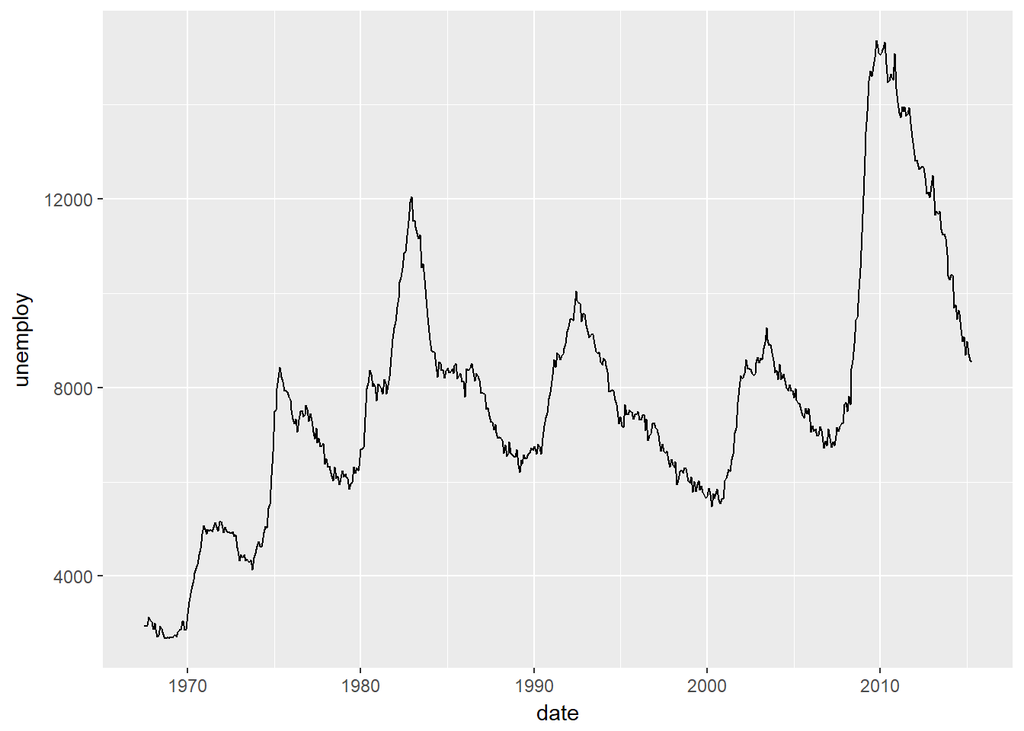

```r
library(tidyverse)
ggplot(economics, aes(date, unemploy)) +
  geom_line()
```

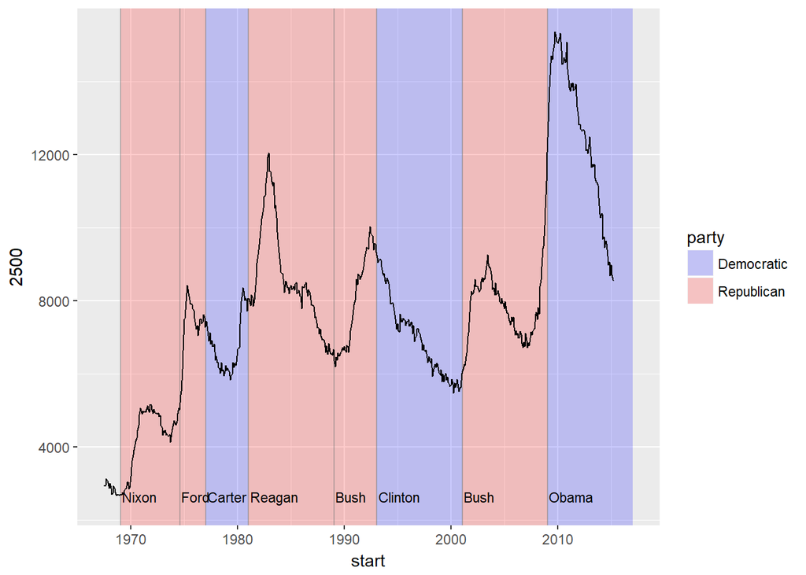

```r
presidential <- subset(presidential, start > economics$date[1])
ggplot(economics) +
  geom_rect(
    aes(xmin = start, xmax = end, fill = party),
    ymin = -Inf, ymax = Inf, alpha = 0.2,
    data = presidential
  ) +
  geom_vline(
    aes(xintercept = as.numeric(start)),
    data = presidential,
    colour = "grey50", alpha = 0.5
  ) +
  geom_text(
    aes(x = start, y = 2500, label = name),
    data = presidential,
    size = 3, vjust = 0, hjust = 0, nudge_x = 50
  ) +
  geom_line(aes(date, unemploy)) +
  scale_fill_manual(values = c("blue", "red"))
```

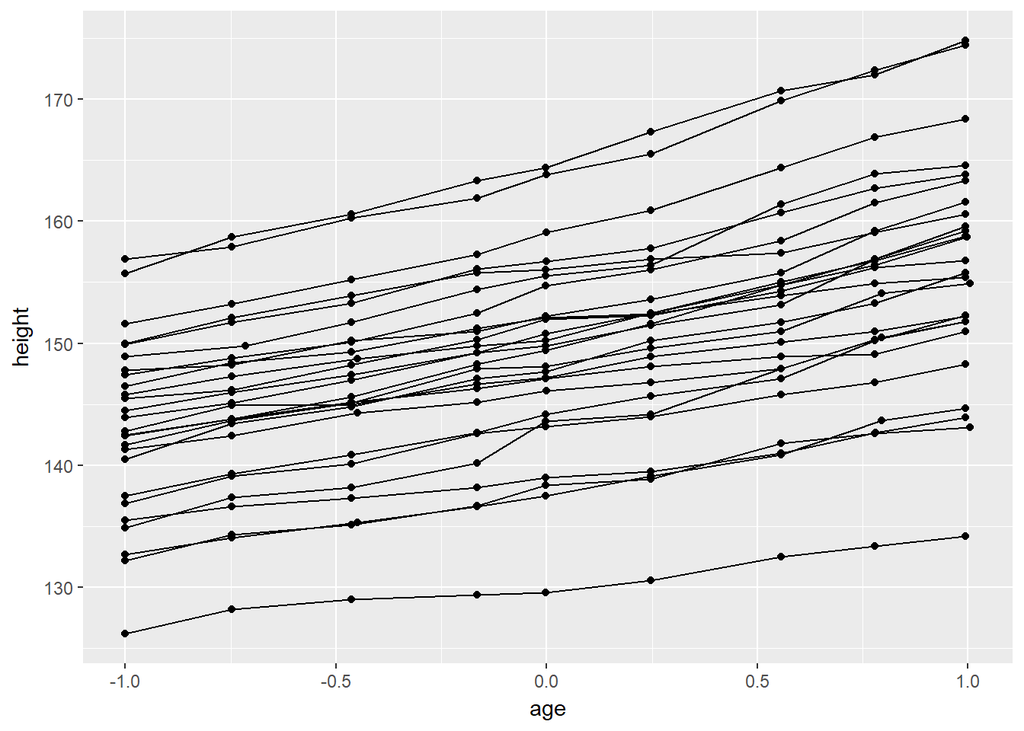

```r
ggplot(nlme::Oxboys, aes(age, height, group = Subject)) +
  geom_point() +
  geom_line()
```

## 3.5.5 Exercises

```r
library(tidyverse)
head(mpg)
```

```
# A tibble: 6 x 11
  manufacturer model displ  year   cyl      trans   drv   cty   hwy    fl
         <chr> <chr> <dbl> <int> <int>      <chr> <chr> <int> <int> <chr>
1         audi    a4   1.8  1999     4   auto(l5)     f    18    29     p
2         audi    a4   1.8  1999     4 manual(m5)     f    21    29     p
3         audi    a4   2.0  2008     4 manual(m6)     f    20    31     p
4         audi    a4   2.0  2008     4   auto(av)     f    21    30     p
5         audi    a4   2.8  1999     6   auto(l5)     f    16    26     p
6         audi    a4   2.8  1999     6 manual(m5)     f    18    26     p
# ... with 1 more variables: class <chr>
```

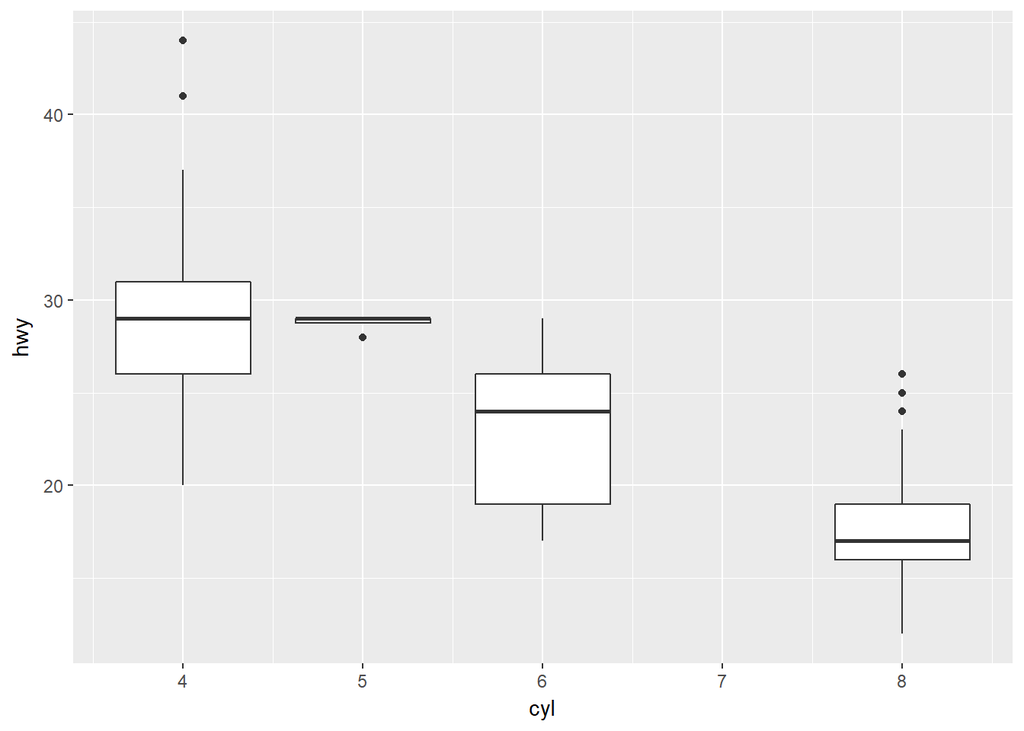

```r
mpg %>%
  ggplot(aes(x = cyl, y = hwy)) +
  geom_boxplot(aes(group = cyl))
```

* I need to set group aesthetic and set it to cyl

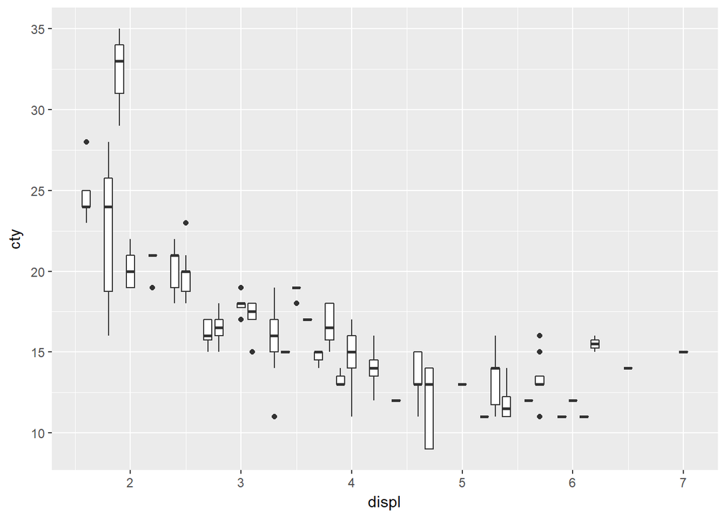

```r
mpg %>%
  ggplot(aes(displ, cty)) +
  geom_boxplot(aes(group = displ))
```

3. Tricky

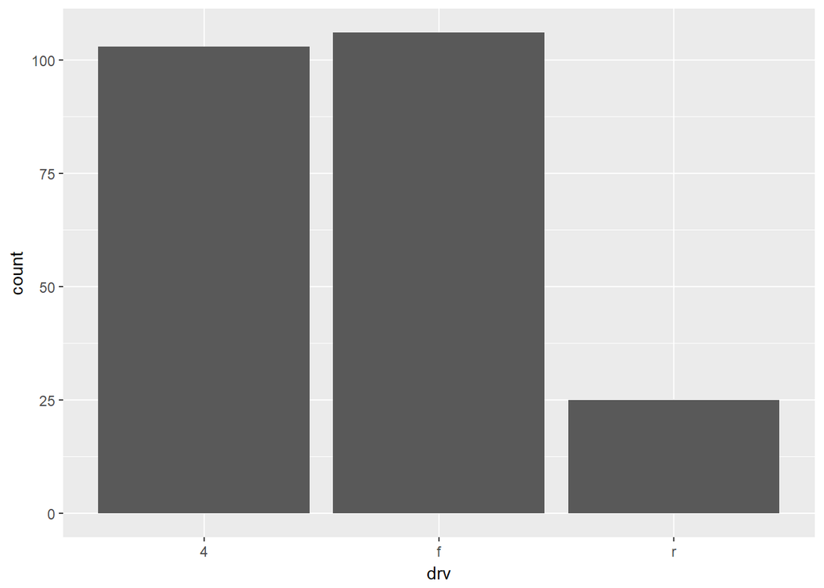

```r
ggplot(mpg, aes(drv)) +
  geom_bar() # 3 bars
```